# Case FortBrasil

```python
pip install haversine
```

```python
!pip install folium
```

```python
#Importando as bibliotecas

import numpy as np
import pandas as pd
import matplotlib.pyplot as plt
import seaborn as sns

from haversine import haversine

import folium
from folium.plugins import MarkerCluster
from folium.plugins import HeatMap

from sklearn.model_selection import train_test_split
from sklearn.ensemble import RandomForestRegressor
from sklearn.datasets import make_regression
from sklearn import linear_model
from sklearn.metrics import mean_squared_error
from sklearn.metrics import r2_score
from sklearn.tree import DecisionTreeRegressor
from sklearn.ensemble import AdaBoostRegressor
from sklearn.ensemble import GradientBoostingRegressor
```

## 1 - Conhecendo o banco de dados

```python
#Importando o banco de dados
df = pd.read_csv("Questão 1 - Base.txt ", delim_whitespace = True)
```

```python
#Ler as 5 primeiras linhas do banco
df.head()
```

|  | ID_CONTA | DT_VENCIMENTO | DS_ROLAGEM | VL_FATURA |
| --- | --- | --- | --- | --- |
| 0 | 402467 | 2019-01-01 | FX0 | 210.00 |
| 1 | 403001 | 2019-01-01 | FX1 | 1097.18 |
| 2 | 403499 | 2019-01-01 | FX0 | 1209.88 |
| 3 | 403670 | 2019-01-01 | FX0 | 667.40 |
| 4 | 404183 | 2019-01-01 | FX1 | 1239.52 |

```python
#Informação sobre o tipo de cada coluna do DataFrame
df.info()
```

```
<class 'pandas.core.frame.DataFrame'>
RangeIndex: 2728249 entries, 0 to 2728248
Data columns (total 4 columns):
 #   Column         Dtype
---  ------         -----
 0   ID_CONTA       int64
 1   DT_VENCIMENTO  object
 2   DS_ROLAGEM     object
 3   VL_FATURA      float64
dtypes: float64(1), int64(1), object(2)
memory usage: 83.3+ MB
```

```python
# Resumo Estatístico de Campos Numéricos
df.describe()
```

|  | ID_CONTA | VL_FATURA |
| --- | --- | --- |
| count | 2.728249e+06 | 2.728249e+06 |
| mean | 1.263072e+06 | 5.043950e+02 |
| std | 3.695060e+05 | 5.166548e+02 |
| min | 2.763700e+04 | 3.000000e+01 |
| 25% | 1.040601e+06 | 1.747500e+02 |
| 50% | 1.375717e+06 | 3.541100e+02 |
| 75% | 1.562847e+06 | 6.506900e+02 |
| max | 1.752194e+06 | 2.264748e+04 |

```python
# Resumo Estatístico de Campos Categóricos
df.describe(include='O')
```

|  | DT_VENCIMENTO | DS_ROLAGEM |
| --- | --- | --- |
| count | 2728249 | 2728249 |
| unique | 97 | 2 |
| top | 2019-01-10 | FX0 |
| freq | 55900 | 2481796 |

```python
#Transformando a variável 'DS_ROLAGEM' em 0 e 1, onde 0= o cliente pagou a fatura anterior e
#1= o cliente não pagou a fatura anterior

df = pd.get_dummies(df,columns=['DS_ROLAGEM'],drop_first=True)
```

```python
#Lendo o banco de dados
df
```

|  | ID_CONTA | DT_VENCIMENTO | VL_FATURA | DS_ROLAGEM_FX1 |
| --- | --- | --- | --- | --- |
| 0 | 402467 | 2019-01-01 | 210.00 | 0 |
| 1 | 403001 | 2019-01-01 | 1097.18 | 1 |
| 2 | 403499 | 2019-01-01 | 1209.88 | 0 |
| 3 | 403670 | 2019-01-01 | 667.40 | 0 |
| 4 | 404183 | 2019-01-01 | 1239.52 | 1 |
| ... | ... | ... | ... | ... |
| 2728244 | 1624841 | 2019-08-08 | 1467.05 | 1 |
| 2728245 | 1624848 | 2019-08-08 | 1189.15 | 0 |
| 2728246 | 1624871 | 2019-08-08 | 427.72 | 1 |
| 2728247 | 1624878 | 2019-08-08 | 281.14 | 0 |
| 2728248 | 1624884 | 2019-08-08 | 313.00 | 0 |

2728249 rows × 4 columns

O negócio da Fortbrasil consiste na oferta de crédito rápido e consciente para parceiros e clientes de classes emergentes, tendo como principal produto o cartão de crédito. Com isso, deseja-se encontrar o percentual de faturas emitidas por mês na qual os clientes não pagaram a Fatura Anterior.

## Percentual de faturas emitidas por mês no qual os clientes não pagaram a fatura anterior

Para tornar o processo mais simples foi extraído somente a informação do mês da coluna DT_VENCIMENTO

```python
#Criando uma coluna com o mês da fatura
df['MES_VENC'] = df['DT_VENCIMENTO'].str.extract('-(\d+)')
```

```python
#Localizando um ID aleatório para testar
df[['ID_CONTA','DT_VENCIMENTO','DS_ROLAGEM_FX1', 'MES_VENC']].loc[df['ID_CONTA']==1624754]
```

|  | ID_CONTA | DT_VENCIMENTO | DS_ROLAGEM_FX1 | MES_VENC |
| --- | --- | --- | --- | --- |
| 392656 | 1624754 | 2019-02-08 | 0 | 02 |
| 886217 | 1624754 | 2019-03-08 | 1 | 03 |
| 1076251 | 1624754 | 2019-09-08 | 0 | 09 |
| 1505222 | 1624754 | 2019-04-08 | 0 | 04 |
| 1797695 | 1624754 | 2019-05-08 | 0 | 05 |
| 2110703 | 1624754 | 2019-06-08 | 1 | 06 |
| 2405414 | 1624754 | 2019-07-08 | 0 | 07 |
| 2728234 | 1624754 | 2019-08-08 | 1 | 08 |

```python
#Gerando tabela de frequência
tabela_pg_mes = pd.crosstab(df['MES_VENC'], df['DS_ROLAGEM_FX1'], margins=True)
```

```python
tabela_pg_mes
```

| DS_ROLAGEM_FX1 MES_VENC | 0 | 1 | All |
| --- | --- | --- | --- |
| 01 | 290548 | 22835 | 313383 |
| 02 | 285921 | 27928 | 313849 |
| 03 | 273886 | 33432 | 307318 |
| 04 | 276950 | 25380 | 302330 |
| 05 | 271544 | 30321 | 301865 |
| 06 | 278389 | 25977 | 304366 |
| 07 | 281005 | 29889 | 310894 |
| 08 | 288331 | 28736 | 317067 |
| 09 | 235222 | 21955 | 257177 |
| All | 2481796 | 246453 | 2728249 |

```python
##tabeladf = (pd.DataFrame(tabela_pg_mes))
##tabeladf
```

[output not shown]

```python
#Usou-se o Excel para calcular as porcentagens contidas em percent.
percent = [7.29, 8.90, 10.88, 8.39, 10.04, 8.53, 9.61, 9.06, 8.54, '-']
```

```python
tabeladf['Percentual'] = percent
```

```python
tabeladf
```

| DS_ROLAGEM_FX1 MES_VENC | 0 | 1 | All | Percentual |
| --- | --- | --- | --- | --- |
| 01 | 290548 | 22835 | 313383 | 7.29 |
| 02 | 285921 | 27928 | 313849 | 8.9 |
| 03 | 273886 | 33432 | 307318 | 10.88 |
| 04 | 276950 | 25380 | 302330 | 8.39 |
| 05 | 271544 | 30321 | 301865 | 10.04 |
| 06 | 278389 | 25977 | 304366 | 8.53 |
| 07 | 281005 | 29889 | 310894 | 9.61 |
| 08 | 288331 | 28736 | 317067 | 9.06 |
| 09 | 235222 | 21955 | 257177 | 8.54 |
| All | 2481796 | 246453 | 2728249 | - |

```python
percentual = [7.29, 8.90, 10.88, 8.39, 10.04, 8.53, 9.61, 9.06, 8.54]
```

```python
mes = ['Janeiro', 'Fevereiro', 'Março', 'Abril', 'Maio', 'Junho','Julho', 'Agosto', 'Setembro']
```

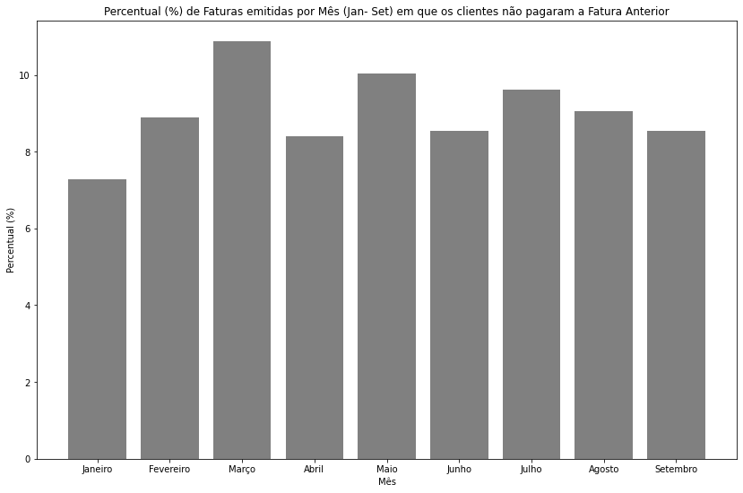

```python
plt.figure(figsize=(14,9))
plt.bar(mes, percentual, color = 'grey')
plt.xticks(mes)
#plt.ylim(0,100)
plt.ylabel('Percentual (%)')
plt.xlabel('Mês')
plt.title('Percentual (%) de Faturas emitidas por Mês (Jan- Set) em que os clientes não pagaram a Fatura Anterior')
plt.show()
```

Para melhor visualização foi gerado um gráfico, onde nota-se que nesse cenário as Faturas emitidas no mês de Março possui maior percentual (10,88%) em relação aos clientes que não pagam a fatura anterior, seguido do mês de Maio (10,04%).

Além disso, deseja-se gerar uma base tendo como referência todos os clientes que tiveram fatura emitida no mês de setembro, contendo o total de faturas emitidas, o valor médio de fatura e a quantidade de vezes que o cliente ficou sem pagar a fatura anterior levando em consideração os últimos 6 meses (sem contar o mês de setembro). Para isso, iremos gerar primeiro uma base com os ID_CONTA que tiveram fatura emitida em setembro.

## Gerando os ID_CONTA que tiveram faturas emitidas em setembro

```python
df.columns
```

```
Index(['ID_CONTA', 'DT_VENCIMENTO', 'VL_FATURA', 'DS_ROLAGEM_FX1', 'MES_VENC'], dtype='object')
```

```python
#Foi necessário alterar o tipo da coluna criada (MES_VENC)
df['MES_VENC'] = df['MES_VENC'].astype(int)
```

```python
#localizar os id's das faturas que foram emitidas em setembro

COL_ID = df[['ID_CONTA']].loc[(df['MES_VENC']==9)]
```

```python
#Criar uma coluna contendo a qtd de faturas emitidas nos últimos 6 meses
df['FATURA_6_MESES']= '1'
df['FATURA_6_MESES'] = df['FATURA_6_MESES'].astype(int)
```

```python
#Juntando o banco criado contendo os Id's com o banco principal para encontrar a interseção dos dois
df_merge=df.merge(COL_ID)
```

A partir desse momento já temos o nosso banco criado, porém, precisamos somente dos últimos 6 meses. Para isso, iremos filtrar somente os meses que nos interessam.

```python
#Faturas de Setembro (Filtrar pelos últimos 6 meses Mar~Ago)
df_merge_1 = df_merge[['ID_CONTA','DT_VENCIMENTO','DS_ROLAGEM_FX1', 'MES_VENC', 'VL_FATURA', 'FATURA_6_MESES']].\
loc[(df_merge['MES_VENC']>=3) & (df_merge['MES_VENC']<=8)]
```

## Fazendo um agrupamento para obter a coluna

A coluna FATURA_6_MESES indicada aqui, contém a quantidade de faturas nos últimos 6 meses.

```python
#Agrupar por ID
df_merge1_agrupado= df_merge_1.groupby(by=['ID_CONTA'])['FATURA_6_MESES'].sum()
```

```python
df_merge1_agrupado = df_merge1_agrupado.reset_index()
```

```python
#Banco com a quantidade de faturas nos últimos 6 meses.
df_merge1_agrupado
```

[output not shown]

```python
#Verificação
#df_merge1_agrupado[['ID_CONTA', 'FATURA_6_MESES']].loc[df_merge1_agrupado['ID_CONTA']==1624754]
```

[output not shown]

## Calculando o valor médio de fatura por id para os últimos 6 meses

Seguiremos os mesmos passos acima para criar a coluna de valor médio.

```python
df_merge_2_agrupado=df_merge_1.groupby(by=['ID_CONTA'])['VL_FATURA'].mean()
```

```python
df_merge_2_agrupado = df_merge_2_agrupado.reset_index()
```

```python
#Ver banco
df_merge_2_agrupado
```

[output not shown]

## Calculando a quantidade de vezes que o cliente deixou de pagar nos últimos 6 meses

```python
df_merge_3_agrupado=df_merge_1.groupby(by=['ID_CONTA'])['DS_ROLAGEM_FX1'].sum()
```

```python
df_merge_3_agrupado = df_merge_3_agrupado.reset_index()
```

```python
df_merge_3_agrupado.iloc[29931]
```

```
ID_CONTA          755522
DS_ROLAGEM_FX1         1
Name: 29931, dtype: int64
```

## Tabela criada com os dados solicitados

Agora que já temos nossos dados necessários, iremos fazer um merge() das tabelas para obtermos nosso banco de dados final.

```python
data_final = df_merge1_agrupado.merge(df_merge_2_agrupado)
```

```python
data_final = data_final.merge(df_merge_3_agrupado)
```

```python
data_final.columns = ['ID_CONTA', 'QTD_FATURAS_ULT_6M', 'VL_MEDIO_FATURA', 'QTD_FATURAS_ULT_6M_FX1']
```

```python
#Banco final
data_final
```

|  | ID_CONTA | QTD_FATURAS_ULT_6M | VL_MEDIO_FATURA | QTD_FATURAS_ULT_6M_FX1 |
| --- | --- | --- | --- | --- |
| 0 | 27717 | 6 | 1623.128333 | 0 |
| 1 | 27789 | 6 | 913.355000 | 0 |
| 2 | 30256 | 6 | 441.881667 | 0 |
| 3 | 35473 | 6 | 882.268333 | 0 |
| 4 | 35510 | 6 | 1376.676667 | 0 |
| ... | ... | ... | ... | ... |
| 240237 | 1733074 | 1 | 110.690000 | 0 |
| 240238 | 1733098 | 1 | 204.370000 | 0 |
| 240239 | 1733273 | 1 | 121.820000 | 0 |
| 240240 | 1733278 | 1 | 107.690000 | 0 |
| 240241 | 1733288 | 1 | 69.660000 | 0 |

240242 rows × 4 columns